# Vectors, Matrices, Multidimensionals Arrays

# Creating Arrays

## Arrays Created from Lists and Other Array-Like Objects

```python
data = np.array([1, 2, 3, 4])
```

```python
data.ndim
```

```
1
```

```python
data.shape
```

```
(4,)
```

```python
data.size
```

```
4
```

```python
data = np.array((1, 2, 3, 4))
```

```python
data
```

```
array([1, 2, 3, 4])
```

```python
data.shape
```

```
(4,)
```

```python
data = np.array({1, 2, 3, 4})
```

```python
data
```

```
array({1, 2, 3, 4}, dtype=object)
```

```python
data = np.array([[1, 2],
                 [3, 4]])
```

```python
data
```

```
array([[1, 2],
       [3, 4]])
```

```python
data.shape
```

```
(2, 2)
```

## Arrays Filled with Constant Values

```python
np.zeros(5)
```

```
array([0., 0., 0., 0., 0.])
```

```python
np.zeros((3, 4))
```

[output not shown]

```python
np.ones(10)
```

[output not shown]

```python
np.ones((5, 5))
```

```
array([[1., 1., 1., 1., 1.],
       [1., 1., 1., 1., 1.],
       [1., 1., 1., 1., 1.],
       [1., 1., 1., 1., 1.],
       [1., 1., 1., 1., 1.]])
```

```python
data = np.ones(4)
```

```python
data
```

[output not shown]

```python
data.dtype
```

[output not shown]

```python
data = np.ones(4, dtype = int)
```

```python
data
```

```
array([1, 1, 1, 1])
```

```python
data.dtype
```

```
dtype('int32')
```

```python
x1 = 8.3 * np.ones(15)
```

```python
x1
```

```
array([8.3, 8.3, 8.3, 8.3, 8.3, 8.3, 8.3, 8.3, 8.3, 8.3, 8.3, 8.3, 8.3,
       8.3, 8.3])
```

```python
x2 = np.full(15, 8.3)
```

```python
x2
```

```
array([8.3, 8.3, 8.3, 8.3, 8.3, 8.3, 8.3, 8.3, 8.3, 8.3, 8.3, 8.3, 8.3,
       8.3, 8.3])
```

```python
x3 = np.full((4, 3), 8.3)
```

```python
x3
```

```
array([[8.3, 8.3, 8.3],
       [8.3, 8.3, 8.3],
       [8.3, 8.3, 8.3],
       [8.3, 8.3, 8.3]])
```

```python
x4 = np.empty(5)
```

```python
x4
```

```
array([0., 0., 0., 0., 0.])
```

```python
x4.fill(6.9)
```

```python
x4
```

```
array([6.9, 6.9, 6.9, 6.9, 6.9])
```

```python
x5 = np.full(10, 5.8)
```

```python
x5
```

```
array([5.8, 5.8, 5.8, 5.8, 5.8, 5.8, 5.8, 5.8, 5.8, 5.8])
```

## Arrays Filled with Incremental Sequences

```python
# np.arange(start = 0, end (up to but not including), increment = 1)
```

```python
np.arange(0, 10 , 1)
```

```
array([0, 1, 2, 3, 4, 5, 6, 7, 8, 9])
```

```python
np.arange(2)
```

```
array([0, 1])
```

```python
np.arange(0)
```

```
array([], dtype=int32)
```

```python
np.arange(1, 11, 3)
```

```
array([ 1,  4,  7, 10])
```

```python
# np.linspace(start, end ( up to but including), total number of elements in the array)
```

```python
np.linspace(0, 10 , 11, dtype = int)
```

```
array([ 0,  1,  2,  3,  4,  5,  6,  7,  8,  9, 10])
```

```python
np.linspace?
```

[output not shown]

[output cut: 47 more lines]

[output not shown]

```python
np.linspace(0, 10)
```

```
array([ 0.        ,  0.20408163,  0.40816327,  0.6122449 ,  0.81632653,
        1.02040816,  1.2244898 ,  1.42857143,  1.63265306,  1.83673469,
        2.04081633,  2.24489796,  2.44897959,  2.65306122,  2.85714286,
        3.06122449,  3.26530612,  3.46938776,  3.67346939,  3.87755102,
        4.08163265,  4.28571429,  4.48979592,  4.69387755,  4.89795918,
        5.10204082,  5.30612245,  5.51020408,  5.71428571,  5.91836735,
        6.12244898,  6.32653061,  6.53061224,  6.73469388,  6.93877551,
        7.14285714,  7.34693878,  7.55102041,  7.75510204,  7.95918367,
        8.16326531,  8.36734694,  8.57142857,  8.7755102 ,  8.97959184,
        9.18367347,  9.3877551 ,  9.59183673,  9.79591837, 10.        ])
```

```python
np.linspace(0, 10 , 11, endpoint = False)
```

```
array([0.        , 0.90909091, 1.81818182, 2.72727273, 3.63636364,
       4.54545455, 5.45454545, 6.36363636, 7.27272727, 8.18181818,
       9.09090909])
```

```python
np.arange?
```

[output not shown]

[output cut: 11 more lines]

[output not shown]

## Arrays Filled with Logarithmic Sequences

```python
np.logspace(0, 3, 20) # 20 data points between 10**0 =1 to 10**3 = 1000
```

```
array([   1.        ,    1.43844989,    2.06913808,    2.97635144,
          4.2813324 ,    6.15848211,    8.8586679 ,   12.74274986,
         18.32980711,   26.36650899,   37.92690191,   54.55594781,
         78.47599704,  112.88378917,  162.37767392,  233.57214691,
        335.98182863,  483.29302386,  695.19279618, 1000.        ])
```

```python
np.logspace?
```

[output not shown]

[output cut: 42 more lines]

[output not shown]

```python
np.logspace(0, 3, 20, base = 3)
```

```
array([ 1.        ,  1.18941917,  1.41471797,  1.68269268,  2.00142693,
        2.38053557,  2.83145465,  3.36778645,  4.00570977,  4.764468  ,
        5.66694959,  6.7403785 ,  8.01713542,  9.53573458, 11.34198554,
       13.49037507, 16.04571076, 19.08507602, 22.70015534, 27.        ])
```

## Meshgrid Arrays

```python
x = np.array([-1, 0 , 1])
y = np.array([-2, 0 , 2])
```

```python
X, Y = np.meshgrid(x, y)
```

```python
X
```

```
array([[-1,  0,  1],
       [-1,  0,  1],
       [-1,  0,  1]])
```

```python
Y
```

```
array([[-2, -2, -2],
       [ 0,  0,  0],
       [ 2,  2,  2]])
```

```python
x = np.array([-1.5, -1, -0.5, 0, 0.5, 1, 1.5])
```

```python
y = np.array([-2, -1, 0, 1, 2])
```

```python
X, Y = np.meshgrid(x, y)
```

```python
X
```

```
array([[-1.5, -1. , -0.5,  0. ,  0.5,  1. ,  1.5],
       [-1.5, -1. , -0.5,  0. ,  0.5,  1. ,  1.5],
       [-1.5, -1. , -0.5,  0. ,  0.5,  1. ,  1.5],
       [-1.5, -1. , -0.5,  0. ,  0.5,  1. ,  1.5],
       [-1.5, -1. , -0.5,  0. ,  0.5,  1. ,  1.5]])
```

```python
Y
```

```
array([[-2, -2, -2, -2, -2, -2, -2],
       [-1, -1, -1, -1, -1, -1, -1],
       [ 0,  0,  0,  0,  0,  0,  0],
       [ 1,  1,  1,  1,  1,  1,  1],
       [ 2,  2,  2,  2,  2,  2,  2]])
```

```python
z = (X + Y) ** 2
```

```python
z
```

```
array([[12.25,  9.  ,  6.25,  4.  ,  2.25,  1.  ,  0.25],
       [ 6.25,  4.  ,  2.25,  1.  ,  0.25,  0.  ,  0.25],
       [ 2.25,  1.  ,  0.25,  0.  ,  0.25,  1.  ,  2.25],
       [ 0.25,  0.  ,  0.25,  1.  ,  2.25,  4.  ,  6.25],
       [ 0.25,  1.  ,  2.25,  4.  ,  6.25,  9.  , 12.25]])
```

```python
# np.mgrid, np.ogrid
```

## Creating Uninitialized Arrays

```python
np.empty(10, dtype = float)
```

```
array([0.90909091, 1.81818182, 2.72727273, 3.63636364, 4.54545455,
       5.45454545, 6.36363636, 7.27272727, 8.18181818, 9.09090909])
```

## Creating Arrays with Properties of Other Arrays

```python
# np.ones_like, np.zeros_like, np.full_like, np.empty_like
```

```python
def f(x):
    y = np.ones_like(x)
    return y
```

```python
x = np.array([1, 5, 8, 9, 12], dtype = complex)
```

```python
x
```

```
array([ 1.+0.j,  5.+0.j,  8.+0.j,  9.+0.j, 12.+0.j])
```

```python
f(x)
```

```
array([1.+0.j, 1.+0.j, 1.+0.j, 1.+0.j, 1.+0.j])
```

## Creating Matrix Arrays

```python
# np.array([[], []])
```

```python
np.identity(5)
```

```
array([[1., 0., 0., 0., 0.],
       [0., 1., 0., 0., 0.],
       [0., 0., 1., 0., 0.],
       [0., 0., 0., 1., 0.],
       [0., 0., 0., 0., 1.]])
```

```python
np.eye(5)
```

```
array([[1., 0., 0., 0., 0.],
       [0., 1., 0., 0., 0.],
       [0., 0., 1., 0., 0.],
       [0., 0., 0., 1., 0.],
       [0., 0., 0., 0., 1.]])
```

```python
np.eye(5, k = 0)
```

```
array([[1., 0., 0., 0., 0.],
       [0., 1., 0., 0., 0.],
       [0., 0., 1., 0., 0.],
       [0., 0., 0., 1., 0.],
       [0., 0., 0., 0., 1.]])
```

```python
np.eye(5, k = 3)
```

```
array([[0., 0., 0., 1., 0.],
       [0., 0., 0., 0., 1.],
       [0., 0., 0., 0., 0.],
       [0., 0., 0., 0., 0.],
       [0., 0., 0., 0., 0.]])
```

```python
np.eye(5, k = -1)
```

```
array([[0., 0., 0., 0., 0.],
       [1., 0., 0., 0., 0.],
       [0., 1., 0., 0., 0.],
       [0., 0., 1., 0., 0.],
       [0., 0., 0., 1., 0.]])
```

```python
np.diag?
```

[output not shown]

```python
np.diag(np.arange(0, 27, 5))
```

```
array([[ 0,  0,  0,  0,  0,  0],
       [ 0,  5,  0,  0,  0,  0],
       [ 0,  0, 10,  0,  0,  0],
       [ 0,  0,  0, 15,  0,  0],
       [ 0,  0,  0,  0, 20,  0],
       [ 0,  0,  0,  0,  0, 25]])
```

# Indexing and Slicing

```python
# [m = 0: n(up to but not including) = end: p(step) = 1]
```

## One-Dimensional Arrays

```python
a = np.arange(0, 11)
```

```python
a
```

```
array([ 0,  1,  2,  3,  4,  5,  6,  7,  8,  9, 10])
```

```python
a[0]
```

```
0
```

```python
a[-1]
```

```
10
```

```python
a[5]
```

```
5
```

```python
a[-5]
```

```
6
```

```python
a[2:-2]
```

```
array([2, 3, 4, 5, 6, 7, 8])
```

```python
a[2:-2:2]
```

```
array([2, 4, 6, 8])
```

```python
a[:6]
```

[output not shown]

```python
a[-6:]
```

```
array([ 5,  6,  7,  8,  9, 10])
```

```python
a[::-2]
```

```
array([10,  8,  6,  4,  2,  0])
```

```python
a[:]
```

```
array([ 0,  1,  2,  3,  4,  5,  6,  7,  8,  9, 10])
```

```python
a[0:]
```

```
array([ 0,  1,  2,  3,  4,  5,  6,  7,  8,  9, 10])
```

```python
a[0:-1]
```

```
array([0, 1, 2, 3, 4, 5, 6, 7, 8, 9])
```

```python
a[1:8:-1]
```

```
array([], dtype=int32)
```

```python
a[8:1:-1]
```

```
array([8, 7, 6, 5, 4, 3, 2])
```

## Multidimensional Arrays

```python
f = lambda m, n: n + 10 * m
```

```python
A = np.fromfunction(f, (7, 7), dtype = int)
```

```python
A
```

```
array([[ 0,  1,  2,  3,  4,  5,  6],
       [10, 11, 12, 13, 14, 15, 16],
       [20, 21, 22, 23, 24, 25, 26],
       [30, 31, 32, 33, 34, 35, 36],
       [40, 41, 42, 43, 44, 45, 46],
       [50, 51, 52, 53, 54, 55, 56],
       [60, 61, 62, 63, 64, 65, 66]])
```

```python
A[2, 3]
```

```
23
```

```python
A[:, 3]
```

```
array([ 3, 13, 23, 33, 43, 53, 63])
```

```python
A[:2, :4]
```

```
array([[ 0,  1,  2,  3],
       [10, 11, 12, 13]])
```

```python
A[2:, 4:]
```

```
array([[24, 25, 26],
       [34, 35, 36],
       [44, 45, 46],
       [54, 55, 56],
       [64, 65, 66]])
```

```python
A[::3, ::2]
```

```
array([[ 0,  2,  4,  6],
       [30, 32, 34, 36],
       [60, 62, 64, 66]])
```

## Views

```python
f = lambda m ,n : n + 10 * m
a = np.fromfunction(f, (7, 7), dtype = int); a
```

```
array([[ 0,  1,  2,  3,  4,  5,  6],
       [10, 11, 12, 13, 14, 15, 16],
       [20, 21, 22, 23, 24, 25, 26],
       [30, 31, 32, 33, 34, 35, 36],
       [40, 41, 42, 43, 44, 45, 46],
       [50, 51, 52, 53, 54, 55, 56],
       [60, 61, 62, 63, 64, 65, 66]])
```

```python
b = a[::3, ::2]; b
```

[output not shown]

```python
b[:, :] = 100; b
```

```
array([[100, 100, 100, 100],
       [100, 100, 100, 100],
       [100, 100, 100, 100]])
```

```python
a
```

```
array([[100,   1, 100,   3, 100,   5, 100],
       [ 10,  11,  12,  13,  14,  15,  16],
       [ 20,  21,  22,  23,  24,  25,  26],
       [100,  31, 100,  33, 100,  35, 100],
       [ 40,  41,  42,  43,  44,  45,  46],
       [ 50,  51,  52,  53,  54,  55,  56],
       [100,  61, 100,  63, 100,  65, 100]])
```

```python
b[:2, 1:]
```

```
array([[100, 100, 100],
       [100, 100, 100]])
```

```python
c = b[:2, 1:].copy(); c
```

```
array([[100, 100, 100],
       [100, 100, 100]])
```

```python
c[:, :] = -500
```

```python
c
```

```
array([[-500, -500, -500],
       [-500, -500, -500]])
```

```python
b
```

```
array([[100, 100, 100, 100],
       [100, 100, 100, 100],
       [100, 100, 100, 100]])
```

## Fancy Indexing and Boolean-Valued Indexing

```python
A = np.linspace(0, 1, 11); A
```

```
array([0. , 0.1, 0.2, 0.3, 0.4, 0.5, 0.6, 0.7, 0.8, 0.9, 1. ])
```

```python
A[np.array([0, 4, 6])]
```

```
array([0. , 0.4, 0.6])
```

```python
A[0, 4, 6]
```

```
---------------------------------------------------------------------------
IndexError                                Traceback (most recent call last)
~\AppData\Local\Temp/ipykernel_15992/3363190361.py in <module>
----> 1 A[0, 4, 6]

IndexError: too many indices for array: array is 1-dimensional, but 3 were indexed
```

```python
A[[0, 4, 6]]
```

```
array([0. , 0.4, 0.6])
```

```python
A > 0.5
```

```
array([False, False, False, False, False, False,  True,  True,  True,
        True,  True])
```

```python
A[A > 0.5]
```

```
array([0.6, 0.7, 0.8, 0.9, 1. ])
```

```python
A = np.arange(10)
indexes = [1, 3, 5]
B = A[indexes]
print(f'A: {A}')
print(f'B: {B}')
```

```
A: [0 1 2 3 4 5 6 7 8 9]
B: [1 3 5]
```

```python
B[0] = -200
print(f'A: {A}')
print(f'B: {B}')
```

```
A: [0 1 2 3 4 5 6 7 8 9]
B: [-200    3    5]
```

```python
A[indexes] = -200; A
```

```
array([   0, -200,    2, -200,    4, -200,    6,    7,    8,    9])
```

```python
A = np.arange(10); A
```

```
array([0, 1, 2, 3, 4, 5, 6, 7, 8, 9])
```

```python
B = A[A > 5]; B
```

```
array([6, 7, 8, 9])
```

```python
B[0] = -500; B
```

```
array([-500,    7,    8,    9])
```

```python
A
```

```
array([0, 1, 2, 3, 4, 5, 6, 7, 8, 9])
```

```python
A[A > 5] = -500; A
```

```
array([   0,    1,    2,    3,    4,    5, -500, -500, -500, -500])
```

[figure not shown]

## Reshaping and Resizing

```python
data = np.array([[1, 2], [3, 4]])
```

```python
np.reshape(data, (1, 4))
```

```
array([[1, 2, 3, 4]])
```

```python
a = data.reshape((1, 4)); a
```

```
array([[1, 2, 3, 4]])
```

```python
a.shape
```

```
(1, 4)
```

```python
b = data.reshape(4); b
```

```
array([1, 2, 3, 4])
```

```python
b.shape
```

```
(4,)
```

```python
# np.ravel() -> change view , np.flatten() -> give a copy
```

```python
data = np.array([[1, 2], [3, 4]]); data
```

```
array([[1, 2],
       [3, 4]])
```

```python
data.flatten()
```

```
array([1, 2, 3, 4])
```

```python
data.flatten().shape
```

```
(4,)
```

```python
np.shape(data.flatten())
```

```
(4,)
```

```python
data = np.arange(5); data
```

```
array([0, 1, 2, 3, 4])
```

```python
data.shape
```

```
(5,)
```

```python
col = data[:, np.newaxis]; col
```

```
array([[0],
       [1],
       [2],
       [3],
       [4]])
```

```python
col.shape
```

```
(5, 1)
```

```python
row = data[np.newaxis, :]; row
```

```
array([[0, 1, 2, 3, 4]])
```

```python
data = np.arange(5); data
```

```
array([0, 1, 2, 3, 4])
```

```python
np.expand_dims(data, axis = 1) # -> data[:, np.newaxis]
```

```
array([[0],
       [1],
       [2],
       [3],
       [4]])
```

```python
np.expand_dims(data, axis = 0) # -> data[np.newaxis, :]
```

```
array([[0, 1, 2, 3, 4]])
```

```python
data = np.arange(5); data
```

```
array([0, 1, 2, 3, 4])
```

```python
np.vstack((data, data, data, data))
```

```
array([[0, 1, 2, 3, 4],
       [0, 1, 2, 3, 4],
       [0, 1, 2, 3, 4],
       [0, 1, 2, 3, 4]])
```

```python
data
```

```
array([0, 1, 2, 3, 4])
```

```python
np.hstack((data,data,data,data))
```

```
array([0, 1, 2, 3, 4, 0, 1, 2, 3, 4, 0, 1, 2, 3, 4, 0, 1, 2, 3, 4])
```

```python
data = data[:, np.newaxis]
```

```python
data
```

```
array([[0],
       [1],
       [2],
       [3],
       [4]])
```

```python
np.hstack((data, data, data, data))
```

```
array([[0, 0, 0, 0],
       [1, 1, 1, 1],
       [2, 2, 2, 2],
       [3, 3, 3, 3],
       [4, 4, 4, 4]])
```

```python
np.concatenate((data, data, data, data), axis = 1)
```

```
array([[0, 0, 0, 0],
       [1, 1, 1, 1],
       [2, 2, 2, 2],
       [3, 3, 3, 3],
       [4, 4, 4, 4]])
```

```python
data = np.arange(5); data
```

```
array([0, 1, 2, 3, 4])
```

```python
np.concatenate((data, data, data, data), axis = 0)
```

```
array([0, 1, 2, 3, 4, 0, 1, 2, 3, 4, 0, 1, 2, 3, 4, 0, 1, 2, 3, 4])
```

```python
np.concatenate((data, data, data, data), axis = 1)
```

```
---------------------------------------------------------------------------
AxisError                                 Traceback (most recent call last)
~\AppData\Local\Temp/ipykernel_6048/1188247215.py in <module>
----> 1 np.concatenate((data, data, data, data), axis = 1)

<__array_function__ internals> in concatenate(*args, **kwargs)

AxisError: axis 1 is out of bounds for array of dimension 1
```

```python
data = data[np.newaxis, :]; data
```

```
array([[0, 1, 2, 3, 4]])
```

```python
np.concatenate((data, data, data, data), axis = 0)
```

```
array([[0, 1, 2, 3, 4],
       [0, 1, 2, 3, 4],
       [0, 1, 2, 3, 4],
       [0, 1, 2, 3, 4]])
```

```python
np.concatenate((data, data, data, data), axis = 1)
```

```
array([[0, 1, 2, 3, 4, 0, 1, 2, 3, 4, 0, 1, 2, 3, 4, 0, 1, 2, 3, 4]])
```

## Broadcasting Law in NumPy

> luzumi be yek size budan araye ha nist, amma size ha sazgar bashand jam ettefagh mioftad. mehvar ha ya bayad bar ruye yek mabnaye moshtarak tul e yeksan dashte bashand va ya tule yek kodum az anha 1 bashad.

[figure not shown]

## Arithmetic Operations

### Operators for Elementwise Arithmetic Operation on NumPy Arrays

[figure not shown]

```python
x = np.array([[1, 2], [3, 4]]); x
```

```
array([[1, 2],
       [3, 4]])
```

```python
y = np.array([[5, 6], [7, 8]]); y
```

```
array([[5, 6],
       [7, 8]])
```

```python
x + y
```

```
array([[ 6,  8],
       [10, 12]])
```

```python
y - x
```

```
array([[4, 4],
       [4, 4]])
```

```python
x * y
```

```
array([[ 5, 12],
       [21, 32]])
```

```python
x * 2
```

```
array([[2, 4],
       [6, 8]])
```

```python
2 ** x
```

```
array([[ 2,  4],
       [ 8, 16]], dtype=int32)
```

```python
y / 2
```

```
array([[2.5, 3. ],
       [3.5, 4. ]])
```

```python
(y/ 2).dtype
```

```
dtype('float64')
```

```python
x = np.array([1, 2, 3, 4]).reshape((2,2)); x
```

```
array([[1, 2],
       [3, 4]])
```

```python
z = np.array([1, 2, 3, 4])
```

```python
x / z
```

```
---------------------------------------------------------------------------
ValueError                                Traceback (most recent call last)
~\AppData\Local\Temp/ipykernel_6048/2868904118.py in <module>
----> 1 x / z

ValueError: operands could not be broadcast together with shapes (2,2) (4,)
```

```python
z = np.array([[2, 4]])
```

```python
z.shape
```

```
(1, 2)
```

```python
x / z
```

```
array([[0.5, 0.5],
       [1.5, 1. ]])
```

```python
zz = np.concatenate((z ,z), axis = 0); zz
```

```
array([[2, 4],
       [2, 4]])
```

```python
x / zz
```

```
array([[0.5, 0.5],
       [1.5, 1. ]])
```

```python
z = np.array([[2], [4]]); z
```

```
array([[2],
       [4]])
```

```python
z.shape
```

```
(2, 1)
```

```python
x / z
```

```
array([[0.5 , 1.  ],
       [0.75, 1.  ]])
```

```python
z / x
```

```
array([[2.        , 1.        ],
       [1.33333333, 1.        ]])
```

```python
zz = np.concatenate((z, z), axis = 1); zz
```

```
array([[2, 2],
       [4, 4]])
```

```python
x / zz
```

```
array([[0.5 , 1.  ],
       [0.75, 1.  ]])
```

```python
# x = x + y |  x += y (In place operator)
```

## Elementwise Functions

### NumPy Functions for Elementwise Elementary Mathematical Functions

[figure not shown]

```python
x = np.linspace(-1, 1, 11); x
```

```
array([-1. , -0.8, -0.6, -0.4, -0.2,  0. ,  0.2,  0.4,  0.6,  0.8,  1. ])
```

```python
y = np.sin(np.pi * x); y
```

```
array([-1.22464680e-16, -5.87785252e-01, -9.51056516e-01, -9.51056516e-01,
       -5.87785252e-01,  0.00000000e+00,  5.87785252e-01,  9.51056516e-01,
        9.51056516e-01,  5.87785252e-01,  1.22464680e-16])
```

```python
np.round(y, decimals = 5)
```

```
array([-0.     , -0.58779, -0.95106, -0.95106, -0.58779,  0.     ,
        0.58779,  0.95106,  0.95106,  0.58779,  0.     ])
```

### NumPy Functions for Elementwise Mathematical Operations

[figure not shown]

```python
np.add(np.sin(x)**2 , np.cos(x) ** 2)
```

```
array([1., 1., 1., 1., 1., 1., 1., 1., 1., 1., 1.])
```

```python
np.sin(x)**2 + np.cos(x) ** 2
```

```
array([1., 1., 1., 1., 1., 1., 1., 1., 1., 1., 1.])
```

```python
def heaviside(x):
    return 1 if x>0 else 0
```

```python
heaviside(5)
```

```
1
```

```python
heaviside(-5)
```

```
0
```

```python
x = np.linspace(-5 , 5 , 11); x
```

```
array([-5., -4., -3., -2., -1.,  0.,  1.,  2.,  3.,  4.,  5.])
```

```python
heaviside(x)
```

```
---------------------------------------------------------------------------
ValueError                                Traceback (most recent call last)
~\AppData\Local\Temp/ipykernel_9040/1443328523.py in <module>
----> 1 heaviside(x)

~\AppData\Local\Temp/ipykernel_9040/2135315997.py in heaviside(x)
      1 def heaviside(x):
----> 2     return 1 if x>0 else 0

ValueError: The truth value of an array with more than one element is ambiguous. Use a.any() or a.all()
```

```python
heaviside = np.vectorize(heaviside)
```

```python
heaviside(x)
```

```
array([0, 0, 0, 0, 0, 0, 1, 1, 1, 1, 1])
```

```python
heaviside(-3)
```

```
array(0)
```

```python
def heaviside(x):
    return 1.0 * (x > 0)
```

## Aggregate Functions

### NumPy Functions for Calculating Aggregates of NumPy Arrays

[figure not shown]

```python
# np.mean(data) | data.mean()
```

```python
data = np.random.normal(size = (15, 15)); data
```

```
array([[ 9.65902062e-02, -9.07721677e-01,  1.16723803e+00,
         3.67566263e-01, -5.75895256e-01, -1.56814517e-01,
        -5.41257181e-01,  2.22830952e+00,  1.02806566e+00,
         6.57531730e-01, -1.25418649e+00, -2.64031712e-01,
        -8.90088450e-01, -1.51032774e-02, -3.40704562e-01],
       [-6.20874908e-01, -6.59477208e-01, -3.71718250e-01,
        -2.31770143e-01, -8.84834179e-01, -7.56117024e-01,
         1.15035541e+00,  1.82426459e+00, -6.79074145e-01,
        -4.24984183e-01,  6.20873701e-02, -2.46049071e+00,
        -4.74779083e-01, -3.73983079e-01,  1.09242337e+00],
       [ 8.33546128e-01,  1.78947322e+00,  8.11402812e-01,
         1.69684672e-02,  3.74188521e-02, -5.42847927e-01,
         1.13197657e+00, -8.18438158e-01, -6.01928615e-01,
        -1.25159753e+00, -5.93448032e-01,  1.16860355e+00,
        -1.02980399e+00,  6.36123215e-01,  8.30023034e-01],
       [ 1.71240265e-01, -5.74340350e-01,  4.75304824e-01,
         7.13236787e-01,  1.17382373e+00, -9.18379811e-01,
        -1.12849000e-01, -1.21924139e+00, -8.63430237e-01,
         6.11082639e-01, -2.17986776e+00, -1.88198907e+00,
        -2.46002337e-01,  2.58312900e+00, -5.21903467e-01],
       [ 4.44057850e-01, -5.91581273e-01, -7.28954318e-02,
        -1.67553208e+00, -5.92632519e-01, -3.09638207e-01,
         2.32435422e-02,  8.17934054e-01,  6.80482873e-01,
         2.69029230e+00, -8.62156856e-01,  1.09390940e-01,
         4.50016068e-01, -6.32972533e-01,  2.47814456e-02],
       [ 1.53391392e+00,  2.88796068e-01, -1.83171205e-01,
         4.78465930e-01, -1.62516774e+00, -6.51653452e-01,
        -4.51785167e-01,  9.61677474e-01, -1.55062010e-03,
         5.44447815e-01, -9.21585557e-01,  8.43838703e-01,
         1.48459821e+00, -6.99801384e-01, -9.20405604e-01],
       [ 5.76121927e-01, -3.53390875e-01,  8.30625254e-01,
         2.89804058e-01,  1.96014994e+00, -2.91897348e-01,
        -1.56103120e-01, -6.20505724e-01,  7.88314121e-01,
         1.10673050e+00,  2.37003986e-02, -6.50565807e-01,
         1.04233577e+00, -1.30039671e-01, -1.05516961e+00],
       [-7.72371807e-01,  9.87239142e-01,  1.25884169e+00,
         2.27751632e-01,  1.64752238e+00,  2.41279909e+00,
        -1.52295552e+00,  1.28114015e-01, -3.15248483e-01,
         8.62723551e-01,  5.02291285e-01,  1.24406693e-01,
         1.23745557e+00, -2.26893207e-01, -1.21927956e+00],
```

[output cut: 20 more lines]

```
       [-4.82322998e-02, -4.89783742e-01, -1.50605196e+00,
        -3.32715844e-01,  7.53883477e-02,  8.96628165e-01,
         1.11997524e-02, -7.08127448e-01,  2.27980415e-01,
        -2.37269479e-01,  5.05060351e-01,  8.59336705e-01,
        -1.11873260e+00,  1.89788903e+00, -2.70875176e-01],
       [ 6.65079648e-01, -2.92062944e-01,  4.28167726e-02,
        -1.14517109e+00, -1.17562335e+00, -1.57985621e-01,
         9.70839554e-01,  9.71456058e-01,  1.41239805e+00,
        -8.42636955e-01, -1.47816193e+00,  1.28203347e-01,
        -4.46151366e-01, -1.09236386e+00,  1.81221889e+00],
       [-1.01105743e+00, -1.60538202e+00,  2.30666959e-01,
         1.23156846e+00,  1.59446405e+00,  3.17872228e-01,
        -2.55353261e+00, -1.08274855e-02,  1.36427260e-01,
         8.96182406e-01, -1.43112300e+00,  9.71547737e-01,
         3.54745106e-01,  7.69945816e-01,  1.22146037e-01]])
```

```python
np.mean(data)
```

```
0.09339834249582513
```

```python
data.mean()
```

```
0.09339834249582513
```

```python
data = np.random.normal(size = (5, 10, 15))
```

```python
data.sum(axis = 0).shape
```

```
(10, 15)
```

```python
data.sum(axis = (0, 2)).shape
```

```
(10,)
```

```python
data.sum()
```

```
-16.285187474805525
```

```python
data = np.arange(1, 10).reshape((3, 3)); data
```

```
array([[1, 2, 3],
       [4, 5, 6],
       [7, 8, 9]])
```

[figure not shown]

```python
data.sum()
```

```
45
```

```python
data.sum(axis = 0)
```

```
array([12, 15, 18])
```

```python
data.sum(axis = 1)
```

```
array([ 6, 15, 24])
```

```python
np.sum(data, axis = 0)
```

```
array([12, 15, 18])
```

## Boolean Arrays and Conditional Expressions

### NumPy Functions for Conditional and Logical Expressions

[figure not shown]

```python
# <, >, <=, >=, ==, =!
```

```python
a = np.array([1, 2, 3, 4])
```

```python
b = np.array([4, 3, 2, 1])
```

```python
a < b
```

```
array([ True,  True, False, False])
```

```python
(a < b).dtype
```

```
dtype('bool')
```

```python
np.all(a < b)
```

```
False
```

```python
np.any(a < b)
```

```
True
```

```python
if np.all(a < b):
    print('All elements in a is lower than all elements in b.')
elif np.any(a < b):
    print('some elements in a is lower than some elements in b.')
else:
    print('all elements in a is bigger than all elements in b.')
```

```
some elements in a is lower than some elements in b.
```

```python
x = np.array([-2, -1 , 0, 1, 2])
```

```python
x > 0
```

```
array([False, False, False,  True,  True])
```

```python
1.0 * (x > 0)
```

```
array([0., 0., 0., 1., 1.])
```

```python
x * (x > 0)
```

```
array([0, 0, 0, 1, 2])
```

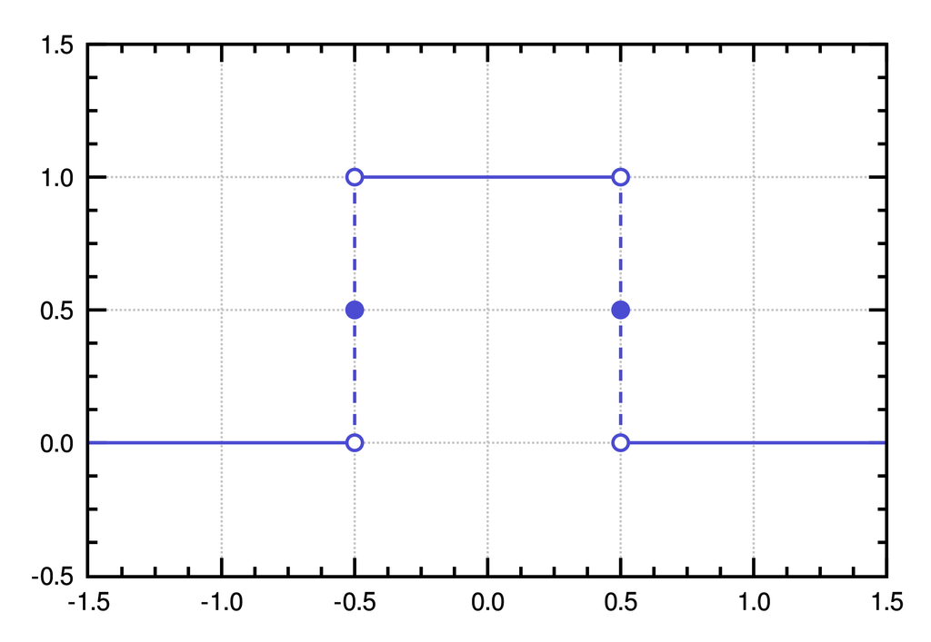

```python
from IPython.display import Image
Image(data = 'PulseFunc.png')
```

```python
# Desing piece wise functions like pulse function
def pulse(x, position, height, width):
    return height * (x >= position) * (x <= (position + width))
```

```python
x = np.linspace(-5, 5, 11); x
```

```
array([-5., -4., -3., -2., -1.,  0.,  1.,  2.,  3.,  4.,  5.])
```

```python
pulse(x, position = -3, height = 5, width = 6)
```

```
array([0, 0, 5, 5, 5, 5, 5, 5, 5, 0, 0])
```

```python
def pulse(x, position, height, width):
    return height * np.logical_and(x >= position, x <= (position + width))
```

```python
pulse(x, position = -3, height = 5, width = 6)
```

```
array([0, 0, 5, 5, 5, 5, 5, 5, 5, 0, 0])
```

```python
x = np.linspace(-4, 4, 9);x
```

```
array([-4., -3., -2., -1.,  0.,  1.,  2.,  3.,  4.])
```

```python
np.where(x < 0 , x**2, x**3)
```

```
array([16.,  9.,  4.,  1.,  0.,  1.,  8., 27., 64.])
```

```python
np.select([x < -1, x < 2, x >= 2], [x**2, x**3, x**4])
```

```
array([ 16.,   9.,   4.,  -1.,   0.,   1.,  16.,  81., 256.])
```

```python
np.choose([0, 0 ,0, 1, 1, 1, 2, 2, 2], [x**2, x**3, x**4])
```

```
array([ 16.,   9.,   4.,  -1.,   0.,   1.,  16.,  81., 256.])
```

```python
x
```

```
array([-4., -3., -2., -1.,  0.,  1.,  2.,  3.,  4.])
```

```python
np.nonzero(abs(x) > 2)
```

```
(array([0, 1, 7, 8], dtype=int64),)
```

```python
x[np.nonzero(abs(x) > 2)]
```

```
array([-4., -3.,  3.,  4.])
```

```python
x[abs(x) > 2]
```

```
array([-4., -3.,  3.,  4.])
```

## Set Operations

### NumPy Functions for Operating on Sets

[figure not shown]

```python
a = np.unique([1, 2, 2, 3, 3, 3]); a
```

```
array([1, 2, 3])
```

```python
b = np.unique([2, 3, 3, 4, 4, 4, 5, 6, 3, 2, 4]); b
```

```
array([2, 3, 4, 5, 6])
```

```python
np.in1d(a, b)
```

```
array([False,  True,  True])
```

```python
a[np.in1d(a, b)]
```

```
array([2, 3])
```

```python
np.in1d(b, a)
```

```
array([ True,  True, False, False, False])
```

```python
1 in a
```

```
True
```

```python
1 in b
```

```
False
```

```python
np.all(np.in1d(a , b))  # subset checking
```

```
False
```

```python
np.union1d(a, b)
```

```
array([1, 2, 3, 4, 5, 6])
```

```python
np.union1d(b, a)
```

```
array([1, 2, 3, 4, 5, 6])
```

```python
np.intersect1d(a, b)
```

```
array([2, 3])
```

```python
np.intersect1d(b, a)
```

```
array([2, 3])
```

```python
np.setdiff1d(a, b)
```

```
array([1])
```

```python
np.setdiff1d(b, a)
```

```
array([4, 5, 6])
```

## Operations on Arrays

### NumPy Functions for Array Operations

[figure not shown]

```python
data = np.arange(9).reshape((3, 3)); data
```

```
array([[0, 1, 2],
       [3, 4, 5],
       [6, 7, 8]])
```

```python
np.transpose(data)
```

```
array([[0, 3, 6],
       [1, 4, 7],
       [2, 5, 8]])
```

```python
data.transpose()
```

```
array([[0, 3, 6],
       [1, 4, 7],
       [2, 5, 8]])
```

```python
data.T
```

```
array([[0, 3, 6],
       [1, 4, 7],
       [2, 5, 8]])
```

```python
data
```

```
array([[0, 1, 2],
       [3, 4, 5],
       [6, 7, 8]])
```

```python
np.fliplr(data)
```

```
array([[2, 1, 0],
       [5, 4, 3],
       [8, 7, 6]])
```

```python
np.flipud(data)
```

```
array([[6, 7, 8],
       [3, 4, 5],
       [0, 1, 2]])
```

```python
np.rot90(data)
```

```
array([[2, 5, 8],
       [1, 4, 7],
       [0, 3, 6]])
```

# Matrix and Vector Operations

### NumPy Functions for Matrix Operations

[figure not shown]

```python
A = np.arange(1, 7).reshape((2, 3)); A
```

```
array([[1, 2, 3],
       [4, 5, 6]])
```

```python
B = np.arange(1, 7).reshape((3, 2)); B
```

```
array([[1, 2],
       [3, 4],
       [5, 6]])
```

```python
# N * M and M * P -> N * P
```

```python
np.dot(A, B)
```

```
array([[22, 28],
       [49, 64]])
```

```python
np.dot(B , A)
```

```
array([[ 9, 12, 15],
       [19, 26, 33],
       [29, 40, 51]])
```

```python
A @ B
```

```
array([[22, 28],
       [49, 64]])
```

```python
B @ A
```

```
array([[ 9, 12, 15],
       [19, 26, 33],
       [29, 40, 51]])
```

```python
A = np.arange(9).reshape((3 , 3)); A
```

```
array([[0, 1, 2],
       [3, 4, 5],
       [6, 7, 8]])
```

```python
x = np.arange(3); x
```

```
array([0, 1, 2])
```

```python
A.shape
```

```
(3, 3)
```

```python
x.shape
```

```
(3,)
```

```python
np.dot(A, x)
```

```
array([ 5, 14, 23])
```

```python
y = np.arange(3).reshape((1, 3)); y
```

```
array([[0, 1, 2]])
```

```python
y.shape
```

```
(1, 3)
```

```python
np.dot(A, y)
```

```
---------------------------------------------------------------------------
ValueError                                Traceback (most recent call last)
~\AppData\Local\Temp/ipykernel_14404/3453443763.py in <module>
----> 1 np.dot(A, y)

<__array_function__ internals> in dot(*args, **kwargs)

ValueError: shapes (3,3) and (1,3) not aligned: 3 (dim 1) != 1 (dim 0)
```

```python
print(y)
print('\n',A)
```

```
[[0 1 2]]

 [[0 1 2]
 [3 4 5]
 [6 7 8]]
```

```python
np.dot(y, A)
```

```
array([[15, 18, 21]])
```

```python
A.dot(x)
```

```
array([ 5, 14, 23])
```

```python
# A_prime = BAB^-1
```

```python
A = np.random.rand(3, 3); A
```

```
array([[0.42444768, 0.08570787, 0.23705496],
       [0.50194924, 0.8918437 , 0.85327381],
       [0.78860255, 0.74432695, 0.87303542]])
```

```python
B = np.random.rand(3, 3); B
```

```
array([[0.46871292, 0.42345985, 0.5602959 ],
       [0.16776235, 0.06976333, 0.65776935],
       [0.62478447, 0.51727267, 0.26160816]])
```

```python
A_prime = np.dot(B ,np.dot(A, np.linalg.inv(B))); A_prime
```

```
array([[ 2.54959175, -0.55123481, -0.39885741],
       [ 1.24304873, -0.06916957,  0.08629156],
       [ 2.10241501, -0.43167853, -0.29109538]])
```

```python
A_prime = B.dot(A.dot(np.linalg.inv(B))); A_prime
```

```
array([[ 2.54959175, -0.55123481, -0.39885741],
       [ 1.24304873, -0.06916957,  0.08629156],
       [ 2.10241501, -0.43167853, -0.29109538]])
```

```python
A = np.matrix(A); A
```

```
matrix([[0.42444768, 0.08570787, 0.23705496],
        [0.50194924, 0.8918437 , 0.85327381],
        [0.78860255, 0.74432695, 0.87303542]])
```

```python
B = np.matrix(B); B
```

```
matrix([[0.46871292, 0.42345985, 0.5602959 ],
        [0.16776235, 0.06976333, 0.65776935],
        [0.62478447, 0.51727267, 0.26160816]])
```

```python
A_prime = B * A * B.I; A_prime
```

```
matrix([[ 2.54959175, -0.55123481, -0.39885741],
        [ 1.24304873, -0.06916957,  0.08629156],
        [ 2.10241501, -0.43167853, -0.29109538]])
```

```python
A = np.random.rand(3, 3); A
```

```
array([[0.39468434, 0.4131507 , 0.11883634],
       [0.1883368 , 0.00684695, 0.94127215],
       [0.01192458, 0.18653736, 0.29896111]])
```

```python
B = np.random.rand(3, 3); B
```

```
array([[0.91005693, 0.7889583 , 0.23023307],
       [0.11238977, 0.9456988 , 0.42102974],
       [0.45365817, 0.39384245, 0.38422564]])
```

```python
type(A)
```

```
numpy.ndarray
```

```python
A = np.asmatrix(A)
```

```python
B = np.asmatrix(B)
```

```python
type(A)
```

```
numpy.matrix
```

```python
A_prime = B * A * B.I; A_prime
```

```
matrix([[-0.91548479, -0.02343996,  2.96764898],
        [-1.59612519, -0.07995528,  3.72315548],
        [-0.56756356,  0.04404366,  1.69593247]])
```

```python
A_prime = np.asarray(A_prime); A_prime
```

```
array([[-0.91548479, -0.02343996,  2.96764898],
       [-1.59612519, -0.07995528,  3.72315548],
       [-0.56756356,  0.04404366,  1.69593247]])
```

```python
x
```

```
array([0, 1, 2])
```

```python
np.inner(x, x) # np.inner just accepts vectors
```

```
5
```

```python
np.sum(x * x)
```

```
5
```

```python
np.dot(x, x) # np.dot could accept vbectors with dimensions like 1*N or N*1
```

```
5
```

```python
y = x[:, np.newaxis]; y
```

```
array([[0],
       [1],
       [2]])
```

```python
np.dot(y.T, y)
```

```
array([[5]])
```

## Outer product

### Given two vectors

[figure not shown]

### their outer product u ⊗ v is defined as the m × n matrix A obtained by multiplying each element of u by each element of v:

[figure not shown]

### index notation :

[figure not shown]

### The outer product u ⊗ v is equivalent to a matrix multiplication $ uv^T $, provided that u is represented as a m × 1 column vector and v as a n × 1 column vector (which makes $ v^T $ a row vector). For instance, if m = 4 and n = 3, then

[figure not shown]

> > [Wikipedia](https://en.wikipedia.org/wiki/Outer_product#cite_note-1)

```python
x = np.array([1, 2, 3])
```

```python
np.outer(x, x)
```

```
array([[1, 2, 3],
       [2, 4, 6],
       [3, 6, 9]])
```

## Kronecker product

### If A is an m × n matrix and B is a p × q matrix, then the Kronecker product A ⊗ B is the pm × qn block matrix:

[figure not shown]

### more explicitly:

[figure not shown]

> > [Wikipedia](https://en.wikipedia.org/wiki/Kronecker_product)

```python
np.kron(x, x)
```

```
array([1, 2, 3, 2, 4, 6, 3, 6, 9])
```

```python
np.kron(x[:, np.newaxis], x[np.newaxis, :]) # to act like outer product our inputs shpuld be N*1 and 1*N
```

```
array([[1, 2, 3],
       [2, 4, 6],
       [3, 6, 9]])
```

```python
np.outer(x, x)
```

```
array([[1, 2, 3],
       [2, 4, 6],
       [3, 6, 9]])
```

```python
np.kron(np.ones((2, 2)), np.identity(2))
```

```
array([[1., 0., 1., 0.],
       [0., 1., 0., 1.],
       [1., 0., 1., 0.],
       [0., 1., 0., 1.]])
```

```python
np.kron(np.identity(2), np.ones((2, 2)))
```

```
array([[1., 1., 0., 0.],
       [1., 1., 0., 0.],
       [0., 0., 1., 1.],
       [0., 0., 1., 1.]])
```

## Einstein notation

### scalar product between two vectors x and y: $ x_{n}y_{n} $

### matrix multiplication of A and B : $ A_{mk}B_{kn} $

```python
x = np.arange(1,5)
```

```python
y = np.array([5, 6, 7, 8])
```

```python
np.einsum('n, n', x, y)
```

```
70
```

```python
np.inner(x, y)
```

```
70
```

```python
A = np.arange(9).reshape((3, 3))
```

```python
B = A.T
```

```python
np.einsum('mk, kn', A, B)
```

```
array([[  5,  14,  23],
       [ 14,  50,  86],
       [ 23,  86, 149]])
```

```python
np.alltrue(np.einsum('mk, kn', A, B) == np.dot(A, B))
```

```
True
```

```python
!jupyter nbconvert --to html Numpy.ipynb
```